# Statistical project

- Median of Deviance Residual is Low meaning that the model is not baised. Thus the model is not over or under estimating the output
- Null deviance: A low null deviance implies that the data can be modeled well merely using the intercept. If the null deviance is low, you should consider using few features for modeling the data.
- Residual deviance: A low residual deviance implies that the model you have trained is appropriate.
- These results are somehow reassuring. First, the null deviance is high, which means it makes sense to use more than a single parameter for fitting the model. Second, the residual deviance is relatively low, which indicates that the log likelihood of our model is close to the log likelihood of the saturated model. However, for a well-fitting model, the residual deviance should be close to the degrees of freedom (74), which is not the case here. For example, this could be a result of overdispersion (underdispersion in our case because residual deviance is much lower than )where the variation is greater than predicted by the model. This can happen for a Poisson model when the actual variance exceeds the assumed mean of 𝜇=𝑉𝑎𝑟(𝑌).

##LDA The main purpose of LDA is to find the linear combination of the different variables that persuade a customer to get a bank term deposit and we have two different groups so we can find only one useful discriminant function.

Renaming blue-collar and self-employed in both binary train and test sets

```r
colnames(bin.train)[11] <- "Job_bluecollar"
colnames(bin.train)[16] <- "Job_selfemployed"
colnames(bin.test)[10] <- "Job_bluecollar"
colnames(bin.test)[15] <- "Job_selfemployed"
```

Dropping Housing unknown because of raising errors due to collinearity with Loan unknown

```r
bin.train <- subset(bin.train, select=-c(Housing_unknown))
bin.test <- subset(bin.test, select=-c(Housing_unknown))
```

```r
linear <- lda(y~.,data=bin.train)
linear
```

```
## Call:
## lda(y ~ ., data = bin.train)
##
## Prior probabilities of groups:
##         0         1
## 0.8862957 0.1137043
##
## Group means:
##         Age   Campaign     Pdays Previous.Contacts Emp.var.rate Cons.price.idx
## 0 0.2827080 0.02978086 0.9854601        0.01895681    0.7607132      0.5474033
## 1 0.2941531 0.01940630 0.7916849        0.07117942    0.4470866      0.4470957
##   Cons.conf.idx Euribor3m Employment.number Job_bluecollar Job_entrepreneur
## 0     0.4265200 0.7208477         0.8037802      0.2391312       0.03676293
## 1     0.4610066 0.3335517         0.4953261      0.1400590       0.02790448
##   Job_housemaid Job_management Job_retired Job_selfemployed Job_services
## 0    0.02550687     0.07214898  0.03538605       0.03493856   0.09948022
## 1    0.02092836     0.07298095  0.09605581       0.03353904   0.06895627
##   Job_student Job_technician Job_unemployed Marital_married Marital_single
## 0  0.01655709      0.1658463     0.02419882       0.6118206      0.2741386
## 1  0.06412664      0.1558895     0.03139254       0.5527234      0.3469278
##   Education_basic.6y Education_basic.9y Education_high.school
## 0         0.05776049          0.1650546             0.2400262
## 1         0.04292997          0.1065200             0.2363831
##   Education_professional.course Education_university.degree Housing_yes
## 0                     0.1321813                   0.2982341   0.5227015
## 1                     0.1341562                   0.3799302   0.5446740
##   Loan_unknown  Loan_yes Contact_telephone Month_aug   Month_dec Month_jul
## 0   0.02457747 0.1514922         0.3917593 0.1507349 0.002375133 0.1776187
## 1   0.02280655 0.1435471         0.1671586 0.1408640 0.020123424 0.1389858
##   Month_jun   Month_mar Month_may  Month_nov  Month_oct   Month_sep
## 0 0.1307012 0.007194245 0.3530687 0.10133902 0.01118722 0.008536711
## 1 0.1253019 0.058223772 0.1888919 0.09122619 0.06627314 0.052589214
##   Last.Contact.Day_mon Last.Contact.Day_thu Last.Contact.Day_tue
## 0            0.2100100            0.2072562            0.1955871
## 1            0.1843306            0.2208210            0.2063322
##   Last.Contact.Day_wed Poutcome_nonexistent Poutcome_success
## 0            0.1955182            0.8869574       0.01290833
## 1            0.2020392            0.6748055       0.19318487
##
## Coefficients of linear discriminants:
```

[output cut: 31 more lines]

```
## Month_aug                      0.585413694
## Month_dec                      0.882042476
## Month_jul                      0.181558663
## Month_jun                     -0.518337693
## Month_mar                      1.997633411
## Month_may                     -0.347517141
## Month_nov                     -0.334663956
## Month_oct                     -0.128459535
## Month_sep                     -0.003035936
## Last.Contact.Day_mon          -0.158134491
## Last.Contact.Day_thu           0.022844934
## Last.Contact.Day_tue           0.014834289
## Last.Contact.Day_wed           0.064549694
## Poutcome_nonexistent           0.368945911
## Poutcome_success               1.033230018
```

The discriminant function is -0.0499*age–0.7083*Campaign+…+1.0332*Poutcome_success. We can observe by the prior probabilities that 88.62% of the training set belongs to group 0 and only 11.37% belongs to 1.

```r
p <- predict(linear, bin.test)
```

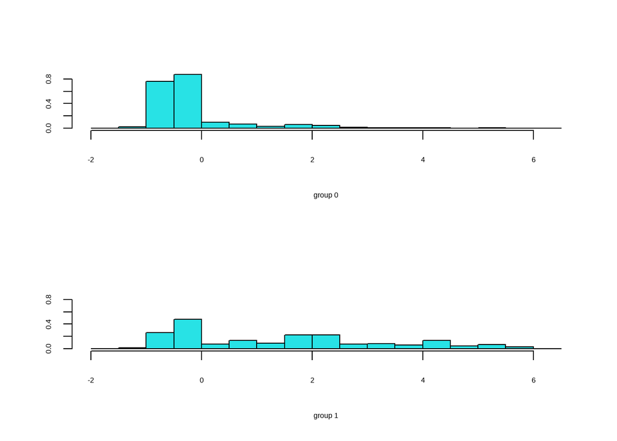

```r
ldahist(data = p$x, g=bin.test.class)
```

We can notice that both groups are overlapping which is not a good signal, so we can infer that there is not a proper separation between the groups.

##LDA confusion matrix

```r
confusionMatrix(table(Predicted=p$class,Actual=bin.test.class))
```

```
## Confusion Matrix and Statistics
##
##          Actual
## Predicted    0    1
##         0 6936  542
##         1  370  346
##
##                Accuracy : 0.8887
##                  95% CI : (0.8817, 0.8954)
##     No Information Rate : 0.8916
##     P-Value [Acc > NIR] : 0.8084
##
##                   Kappa : 0.3705
##
##  Mcnemar's Test P-Value : 1.493e-08
##
##             Sensitivity : 0.9494
##             Specificity : 0.3896
##          Pos Pred Value : 0.9275
##          Neg Pred Value : 0.4832
##              Prevalence : 0.8916
##          Detection Rate : 0.8465
##    Detection Prevalence : 0.9126
##       Balanced Accuracy : 0.6695
##
##        'Positive' Class : 0
##
```

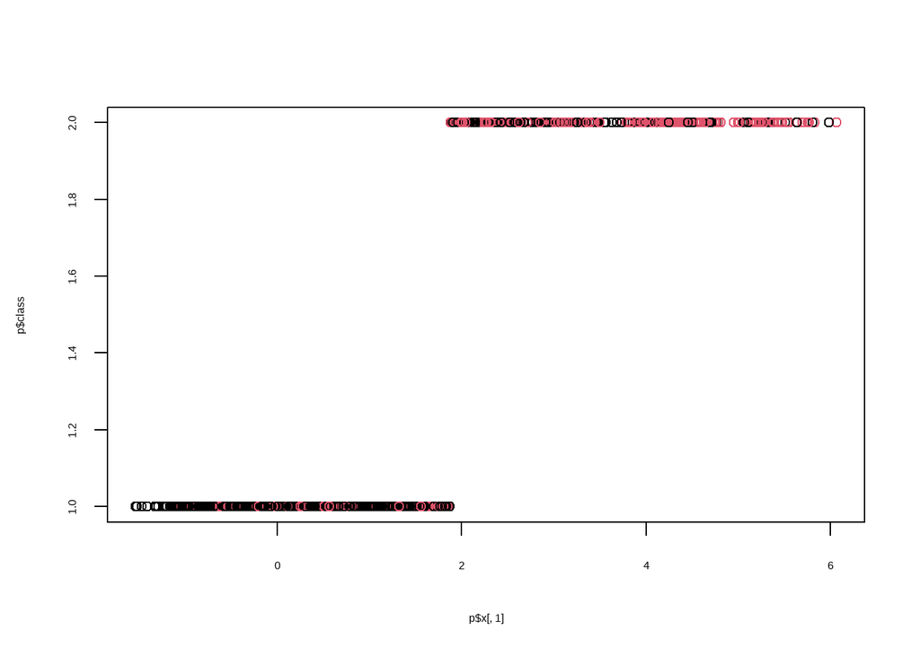

```r
par(mfrow=c(1,1))
plot(p$x[,1], p$class, col=bin.test.class)
```

#AUC-ROC-curve

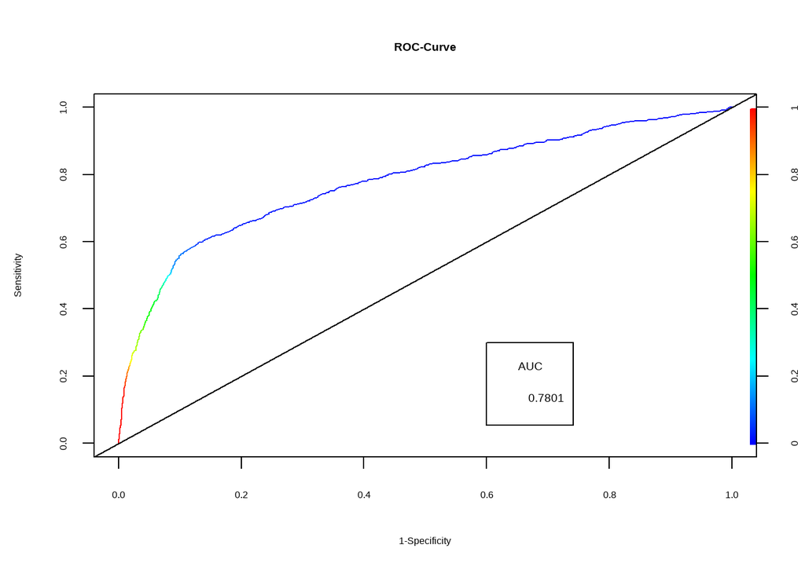

```r
pred <- prediction(p$posterior[,2],bin.test.class)
perf <- performance(pred,"tpr","fpr")
plot(perf,colorize=TRUE,main="ROC-Curve",xlab="1-Specificity",ylab="Sensitivity")
abline(a=0,b=1)
auc <- performance(pred,"auc")
auc <- unlist(slot(auc,"y.values"))
auc <- round(auc,4)
legend(.6,.3,auc,title="AUC",cex = 1.2)
```

**Insights:** - The model gives a AUC score of 78%. Since, the output variable is quite imbalanced and separation of output by variables are not so significant even then LDA performs well on the test set.

##QDA

```r
qda <- qda(y~.,data=bin.train)
qda
```

```
## Call:
## qda(y ~ ., data = bin.train)
##
## Prior probabilities of groups:
##         0         1
## 0.8862957 0.1137043
##
## Group means:
##         Age   Campaign     Pdays Previous.Contacts Emp.var.rate Cons.price.idx
## 0 0.2827080 0.02978086 0.9854601        0.01895681    0.7607132      0.5474033
## 1 0.2941531 0.01940630 0.7916849        0.07117942    0.4470866      0.4470957
##   Cons.conf.idx Euribor3m Employment.number Job_bluecollar Job_entrepreneur
## 0     0.4265200 0.7208477         0.8037802      0.2391312       0.03676293
## 1     0.4610066 0.3335517         0.4953261      0.1400590       0.02790448
##   Job_housemaid Job_management Job_retired Job_selfemployed Job_services
## 0    0.02550687     0.07214898  0.03538605       0.03493856   0.09948022
## 1    0.02092836     0.07298095  0.09605581       0.03353904   0.06895627
##   Job_student Job_technician Job_unemployed Marital_married Marital_single
## 0  0.01655709      0.1658463     0.02419882       0.6118206      0.2741386
## 1  0.06412664      0.1558895     0.03139254       0.5527234      0.3469278
##   Education_basic.6y Education_basic.9y Education_high.school
## 0         0.05776049          0.1650546             0.2400262
## 1         0.04292997          0.1065200             0.2363831
##   Education_professional.course Education_university.degree Housing_yes
## 0                     0.1321813                   0.2982341   0.5227015
## 1                     0.1341562                   0.3799302   0.5446740
##   Loan_unknown  Loan_yes Contact_telephone Month_aug   Month_dec Month_jul
## 0   0.02457747 0.1514922         0.3917593 0.1507349 0.002375133 0.1776187
## 1   0.02280655 0.1435471         0.1671586 0.1408640 0.020123424 0.1389858
##   Month_jun   Month_mar Month_may  Month_nov  Month_oct   Month_sep
## 0 0.1307012 0.007194245 0.3530687 0.10133902 0.01118722 0.008536711
## 1 0.1253019 0.058223772 0.1888919 0.09122619 0.06627314 0.052589214
##   Last.Contact.Day_mon Last.Contact.Day_thu Last.Contact.Day_tue
## 0            0.2100100            0.2072562            0.1955871
## 1            0.1843306            0.2208210            0.2063322
##   Last.Contact.Day_wed Poutcome_nonexistent Poutcome_success
## 0            0.1955182            0.8869574       0.01290833
## 1            0.2020392            0.6748055       0.19318487
```

```r
pred <- predict(qda,bin.test)
```

##qda confusion matrix

```r
confusionMatrix(table(Predicted=pred$class, bin.test.class))
```

```
## Confusion Matrix and Statistics
##
##          bin.test.class
## Predicted    0    1
##         0 6579  411
##         1  727  477
##
##                Accuracy : 0.8611
##                  95% CI : (0.8534, 0.8685)
##     No Information Rate : 0.8916
##     P-Value [Acc > NIR] : 1
##
##                   Kappa : 0.3785
##
##  Mcnemar's Test P-Value : <2e-16
##
##             Sensitivity : 0.9005
##             Specificity : 0.5372
##          Pos Pred Value : 0.9412
##          Neg Pred Value : 0.3962
##              Prevalence : 0.8916
##          Detection Rate : 0.8029
##    Detection Prevalence : 0.8531
##       Balanced Accuracy : 0.7188
##
##        'Positive' Class : 0
##
```

The accuracy is 86%

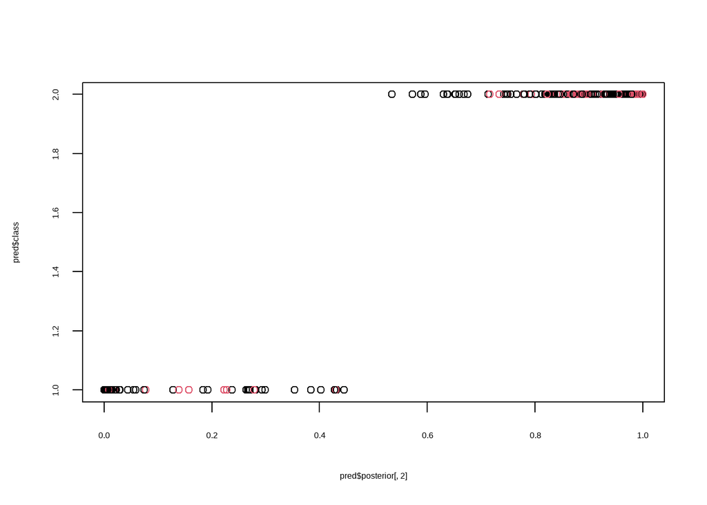

```r
par(mfrow=c(1,1))
plot(pred$posterior[,2], pred$class, col=bin.test.class)
```

AUC-ROC of QDA

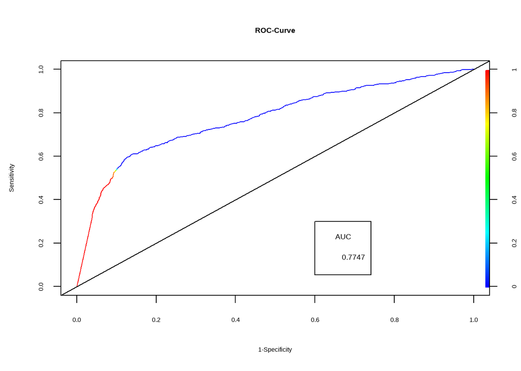

```r
pred <- prediction(pred$posterior[,2],bin.test.class)
perf <- performance(pred,"tpr","fpr")
plot(perf,colorize=TRUE,main="ROC-Curve",xlab="1-Specificity",ylab="Sensitivity")
abline(a=0,b=1)
auc <- performance(pred,"auc")
auc <- unlist(slot(auc,"y.values"))
auc <- round(auc,4)
legend(.6,.3,auc,title="AUC",cex = 1.2)
```

##Knn

```r
library(pROC)
```

KNN is a model that classifies according to the distance of the new observations, usually is used the Euclidean distance for this purpose, and uses the voting method to choose the most frequent label. The inductive bias of this model is that similar points should have similar labels.

```r
classifier_knn <- knn(train = subset(bin.train, select = -c(y)),
                      test = bin.test,
                      cl = bin.train$y,
                      k = 4)
```

```r
# Confusion Matrix
cm <- confusionMatrix(table(Predicted=classifier_knn, Actual=bin.test.class))
cm
```

```
## Confusion Matrix and Statistics
##
##          Actual
## Predicted    0    1
##         0 7024  642
##         1  282  246
##
##                Accuracy : 0.8872
##                  95% CI : (0.8802, 0.894)
##     No Information Rate : 0.8916
##     P-Value [Acc > NIR] : 0.9022
##
##                   Kappa : 0.2901
##
##  Mcnemar's Test P-Value : <2e-16
##
##             Sensitivity : 0.9614
##             Specificity : 0.2770
##          Pos Pred Value : 0.9163
##          Neg Pred Value : 0.4659
##              Prevalence : 0.8916
##          Detection Rate : 0.8572
##    Detection Prevalence : 0.9356
##       Balanced Accuracy : 0.6192
##
##        'Positive' Class : 0
##
```

The accuracy is 88.7% which is similar to the above presented models

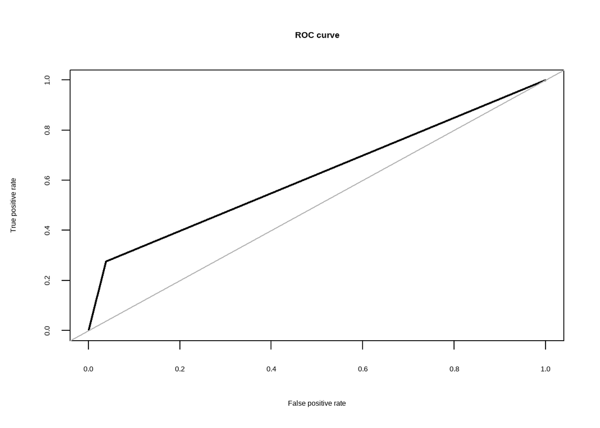

```
## Area under the curve (AUC): 0.619
```

```r
roc.curve(bin.test.class, classifier_knn)
```

It is found that knn has an auc of 61% which is quite low when compared with others

##naive bayes This algorithm follows a probabilistic approach according to the Bayes Theorem, the inductive bias assumes the independence of the predictors. To realize this first the algorithm builds a frequency table, after it creates a likelihood table and finally is calculated the posterior probability for each class and it selects the greatest probability to classify.

```r
classifier_cl <- naiveBayes(y ~ ., data = bin.train, type="prob")

# Predicting on test data'
y_pred <- predict(classifier_cl, newdata = bin.test)

# Confusion Matrix
cm <- table(Predicted=y_pred, Actual=bin.test.class)

# Model Evaluation
confusionMatrix(cm)
```

```
## Confusion Matrix and Statistics
##
##          Actual
## Predicted    0    1
##         0 6760  514
##         1  546  374
##
##                Accuracy : 0.8706
##                  95% CI : (0.8632, 0.8778)
##     No Information Rate : 0.8916
##     P-Value [Acc > NIR] : 1.000
##
##                   Kappa : 0.341
##
##  Mcnemar's Test P-Value : 0.341
##
##             Sensitivity : 0.9253
##             Specificity : 0.4212
##          Pos Pred Value : 0.9293
##          Neg Pred Value : 0.4065
##              Prevalence : 0.8916
##          Detection Rate : 0.8250
##    Detection Prevalence : 0.8877
##       Balanced Accuracy : 0.6732
##
##        'Positive' Class : 0
##
```

The naive bayes is giving an accuracy of 87% less accuracy compared to Knn

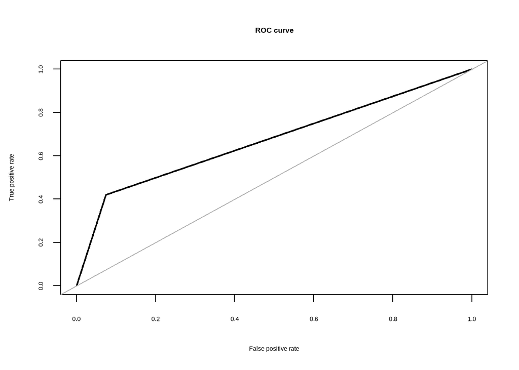

```
## Area under the curve (AUC): 0.673
```

```r
roc.curve(bin.test.class, y_pred)
```

Auc score is 67% which is better than the Auc of knn(61%)

##Conclusions - Interms of Accuracy Logistic regression has an accuracy of 90% and other models have an accuracy ranging betwween 86 to 88% - AUC score is similar for Logistic, LDA and QDA whereas It is not significant in case of knn and naive bayes - Job + Education + Contact + Month + Last.Contact.Day + Campaign + Pdays + Poutcome + Emp.var.rate + Cons.price.idx+Cons.conf.idx + Employment.number decides whether client subscribe the term deposit or not